**Suppplier: ABC Corp # 12345** **Document Control # 1234567890**

# Model XXX - Washer Tank Leaks

### 9/26/16

### Affected Vehicles / Trim Levels / Failed Part Numbers:

- 2015 Model XXX, fail part # 12345 (windshield washer tank assy)

### Market Problem Description / Dealer Repair Method:

Customer states that the washer tank is leaking or that they are consistently refilling their washer fluid. Dealers are replacing the washer tank (**reference # 13 below**).

#### Image from American Honda's Parts Catalog:

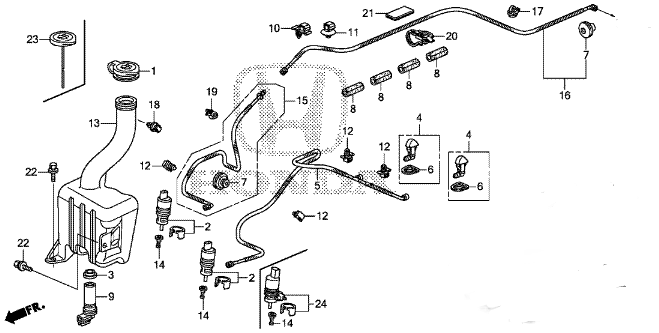

### Root Cause per QIS:

Washer tank cracking is a result of a combination of internal seam thickness with a higher material crystallinity factor. Note: Model years 09M-14M did not experience this warranty trend.

**Before C/M:**

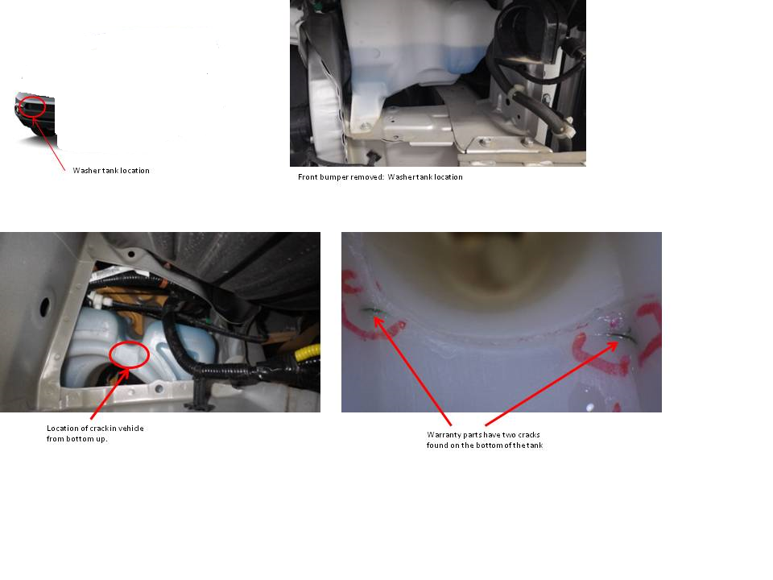

### Countermeasure Activity:

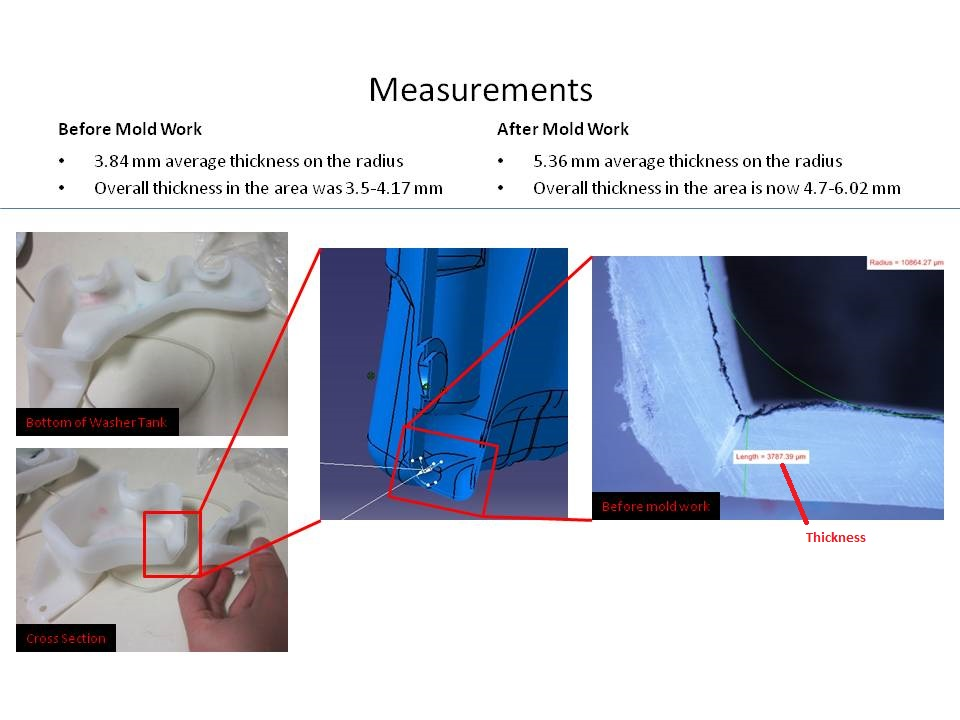